# MT Code Result Analysis 02

Markus Rottmann

2021 04 16

#### Description

This Code is to analyze/build the results from the simulating each countermeasure (in NetLogo).  
The settings for the simulation runs are:

- 2 initial Information Pollution Tweets
- 3 days of Tweet life-span
- 365 days of simulation

**Input**

- `network_sim_warn_01_00_noip2_lstwt3_365_01.csv`
- `network_sim_delay_01_00_noip2_lstwt3_365_01.csv`
- `network_sim_ban_01_00_noip2_lstwt3_365_01.csv`

**Output**

#### 1. Contermeasure “Warning”

4 x 30 Runs are performed. Settings for these simulation runs are:

- Run 1: 0% lowering of probability to post an IP Tweet.
- Run 2: 25% lowering of probability to post an IP Tweet.
- Run 3: 50% lowering of probability to post an IP Tweet.
- Run 4: 75% lowering of probability to post an IP Tweet.

```r
## loading data
data01 <- read.csv2("./RawData/network_sim_warn_01_00_noip2_lstwt3_365_01.csv") %>%
    as.data.frame(.) %>%
    `colnames<-`(c("p_warn", "sum_newip"))

## getting descriptive statistics on base model (strength = 0)
desc01 <- data01 %>%
          filter(., p_warn == 0) %>%
          dplyr::select(., sum_newip)
summary(desc01)
```

```
##    sum_newip
##  Min.   :25376
##  1st Qu.:25593
##  Median :25722
##  Mean   :25706
##  3rd Qu.:25805
##  Max.   :25981
```

```r
desc01 %>%
  pull(.) %>%
  sd(.)
```

```
## [1] 172.0159
```

```r
## performing OLS
res01 <- data01 %>%
  lm(data = ., formula = sum_newip ~ p_warn)

## viewing OLS and saving as .html-table
# viewing results
summary(res01)
```

```
##
## Call:
## lm(formula = sum_newip ~ p_warn, data = .)
##
## Residuals:
##      Min       1Q   Median       3Q      Max
## -11613.4   -174.6    412.6    746.8   1389.6
##
## Coefficients:
##             Estimate Std. Error t value Pr(>|t|)
## (Intercept) 25979.38     296.06   87.75   <2e-16 ***
## p_warn       -287.32       6.33  -45.39   <2e-16 ***
## ---
## Signif. codes:  0 '***' 0.001 '**' 0.01 '*' 0.05 '.' 0.1 ' ' 1
##
## Residual standard error: 1938 on 118 degrees of freedom
## Multiple R-squared:  0.9458, Adjusted R-squared:  0.9454
## F-statistic:  2060 on 1 and 118 DF,  p-value: < 2.2e-16
```

```r
# saving results
res01 %>%
   stargazer(.,
     style = "apsr",
     digits = 2,
     type = "html",
     out = "./PlotsTables/regres_warn_noip2_lstwt3_365_01.html")
```

```
##
## <table style="text-align:center"><tr><td colspan="2" style="border-bottom: 1px solid black"></td></tr><tr><td style="text-align:left"></td><td>sum_newip</td></tr>
## <tr><td colspan="2" style="border-bottom: 1px solid black"></td></tr><tr><td style="text-align:left">p_warn</td><td>-287.32<sup>***</sup></td></tr>
## <tr><td style="text-align:left"></td><td>(6.33)</td></tr>
## <tr><td style="text-align:left">Constant</td><td>25,979.38<sup>***</sup></td></tr>
## <tr><td style="text-align:left"></td><td>(296.06)</td></tr>
## <tr><td style="text-align:left">N</td><td>120</td></tr>
## <tr><td style="text-align:left">R<sup>2</sup></td><td>0.95</td></tr>
## <tr><td style="text-align:left">Adjusted R<sup>2</sup></td><td>0.95</td></tr>
## <tr><td style="text-align:left">Residual Std. Error</td><td>1,938.15 (df = 118)</td></tr>
## <tr><td style="text-align:left">F Statistic</td><td>2,060.28<sup>***</sup> (df = 1; 118)</td></tr>
## <tr><td colspan="2" style="border-bottom: 1px solid black"></td></tr><tr><td colspan="2" style="text-align:left"><sup>*</sup>p < .1; <sup>**</sup>p < .05; <sup>***</sup>p < .01</td></tr>
## </table>
```

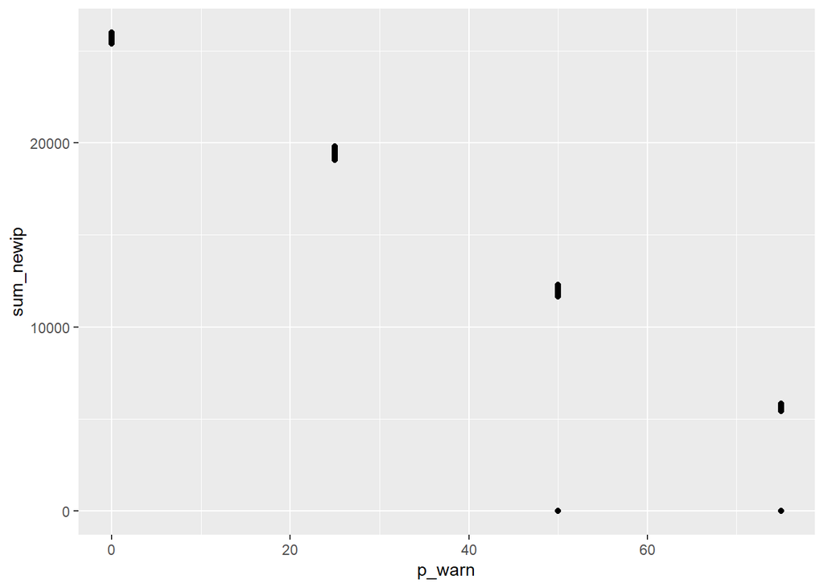

```r
## creating scatter plot and saving
# creating
plt_warn01 <- data01 %>%
            ggplot(.) +
            geom_point(aes(x = p_warn, y = sum_newip))
# plotting
plt_warn01
```

```r
# saving
plt_warn01 %>%
        ggsave(., filename = "./PlotsTables/plt_warn01.png",
               units = "cm",
               dpi = "retina",
               height = 8,
               width = 14)

## removing auxillary variables
rm(list= ls(pattern= "data"))
rm(list= ls(pattern= "res"))
rm(list= ls(pattern= "plt"))
rm(list= ls(pattern= "desc"))
```

#### 2. Contermeasure “Delay”

3 x 30 Runs are performed. Settings for these simulation runs are:

- Run 1: No delay (0 days).
- Run 2: 1 day delay.
- Run 3: 2 days delay.

```r
## loading data
data02 <- read.csv2("./RawData/network_sim_delay_01_00_noip2_lstwt3_365_01.csv") %>%
    as.data.frame(.) %>%
    `colnames<-`(c("d_delay", "sum_newip"))

## getting descriptive statistics on base model (strength = 0)
desc02 <- data02 %>%
          filter(., d_delay == 0) %>%
          dplyr::select(., sum_newip)
summary(desc02)
```

```
##    sum_newip
##  Min.   :    0
##  1st Qu.:25555
##  Median :25673
##  Mean   :24007
##  3rd Qu.:25855
##  Max.   :26128
```

```r
desc02 %>%
  pull(.) %>%
  sd(.)
```

```
## [1] 6528.228
```

```r
## performing OLS
# over entire countermeasure strength
res02 <- data02 %>%
  lm(data = ., formula = sum_newip ~ d_delay)
# over 0 days to 1 day
res02_0t1 <- data02 %>%
   dplyr::filter(., d_delay <= 1) %>%
   lm(data = ., formula = sum_newip ~ d_delay)
# over 1 days to 2 days
res02_1t2 <- data02 %>%
   dplyr::filter(., d_delay >= 1) %>%
   lm(data = ., formula = sum_newip ~ d_delay)

## viewing OLS and saving as .html-table
# over entire strength variation
summary(res02)
```

```
##
## Call:
## lm(formula = sum_newip ~ d_delay, data = .)
##
## Residuals:
##    Min     1Q Median     3Q    Max
## -24627   1072   2765   2988   3330
##
## Coefficients:
##             Estimate Std. Error t value Pr(>|t|)
## (Intercept)  24626.6     1185.8  20.767  < 2e-16 ***
## d_delay      -2846.1      918.6  -3.098  0.00261 **
## ---
## Signif. codes:  0 '***' 0.001 '**' 0.01 '*' 0.05 '.' 0.1 ' ' 1
##
## Residual standard error: 7115 on 88 degrees of freedom
## Multiple R-squared:  0.09836,    Adjusted R-squared:  0.08812
## F-statistic:   9.6 on 1 and 88 DF,  p-value: 0.002612
```

```r
# over 0 days to 1 day
summary(res02_0t1)
```

```
##
## Call:
## lm(formula = sum_newip ~ d_delay, data = .)
##
## Residuals:
##    Min     1Q Median     3Q    Max
## -24007   1533   1658   1792   2121
##
## Coefficients:
##             Estimate Std. Error t value Pr(>|t|)
## (Intercept)  24006.9     1167.7  20.560   <2e-16 ***
## d_delay       -986.9     1651.3  -0.598    0.552
## ---
## Signif. codes:  0 '***' 0.001 '**' 0.01 '*' 0.05 '.' 0.1 ' ' 1
##
## Residual standard error: 6396 on 58 degrees of freedom
## Multiple R-squared:  0.00612,    Adjusted R-squared:  -0.01102
## F-statistic: 0.3572 on 1 and 58 DF,  p-value: 0.5524
```

```r
# over 1 day to 2 days
summary(res02_1t2)
```

```
##
## Call:
## lm(formula = sum_newip ~ d_delay, data = .)
##
## Residuals:
##    Min     1Q Median     3Q    Max
## -23020   1608   1790   3605   3950
##
## Coefficients:
##             Estimate Std. Error t value Pr(>|t|)
## (Intercept)    27725       3009   9.215 5.86e-13 ***
## d_delay        -4705       1903  -2.473   0.0164 *
## ---
## Signif. codes:  0 '***' 0.001 '**' 0.01 '*' 0.05 '.' 0.1 ' ' 1
##
## Residual standard error: 7369 on 58 degrees of freedom
## Multiple R-squared:  0.09537,    Adjusted R-squared:  0.07978
## F-statistic: 6.115 on 1 and 58 DF,  p-value: 0.01636
```

```r
## viewing OLS and saving as .html-table
# viewing results
summary(res02)
```

```
##
## Call:
## lm(formula = sum_newip ~ d_delay, data = .)
##
## Residuals:
##    Min     1Q Median     3Q    Max
## -24627   1072   2765   2988   3330
##
## Coefficients:
##             Estimate Std. Error t value Pr(>|t|)
## (Intercept)  24626.6     1185.8  20.767  < 2e-16 ***
## d_delay      -2846.1      918.6  -3.098  0.00261 **
## ---
## Signif. codes:  0 '***' 0.001 '**' 0.01 '*' 0.05 '.' 0.1 ' ' 1
##
## Residual standard error: 7115 on 88 degrees of freedom
## Multiple R-squared:  0.09836,    Adjusted R-squared:  0.08812
## F-statistic:   9.6 on 1 and 88 DF,  p-value: 0.002612
```

```r
# saving results
res02 %>%
    stargazer(.,
      style = "apsr",
      digits = 2,
      type = "html",
      out = "./PlotsTables/regres_delay_noip2_lstwt3_365_01.html")
```

```
##
## <table style="text-align:center"><tr><td colspan="2" style="border-bottom: 1px solid black"></td></tr><tr><td style="text-align:left"></td><td>sum_newip</td></tr>
## <tr><td colspan="2" style="border-bottom: 1px solid black"></td></tr><tr><td style="text-align:left">d_delay</td><td>-2,846.07<sup>***</sup></td></tr>
## <tr><td style="text-align:left"></td><td>(918.55)</td></tr>
## <tr><td style="text-align:left">Constant</td><td>24,626.62<sup>***</sup></td></tr>
## <tr><td style="text-align:left"></td><td>(1,185.85)</td></tr>
## <tr><td style="text-align:left">N</td><td>90</td></tr>
## <tr><td style="text-align:left">R<sup>2</sup></td><td>0.10</td></tr>
## <tr><td style="text-align:left">Adjusted R<sup>2</sup></td><td>0.09</td></tr>
## <tr><td style="text-align:left">Residual Std. Error</td><td>7,115.09 (df = 88)</td></tr>
## <tr><td style="text-align:left">F Statistic</td><td>9.60<sup>***</sup> (df = 1; 88)</td></tr>
## <tr><td colspan="2" style="border-bottom: 1px solid black"></td></tr><tr><td colspan="2" style="text-align:left"><sup>*</sup>p < .1; <sup>**</sup>p < .05; <sup>***</sup>p < .01</td></tr>
## </table>
```

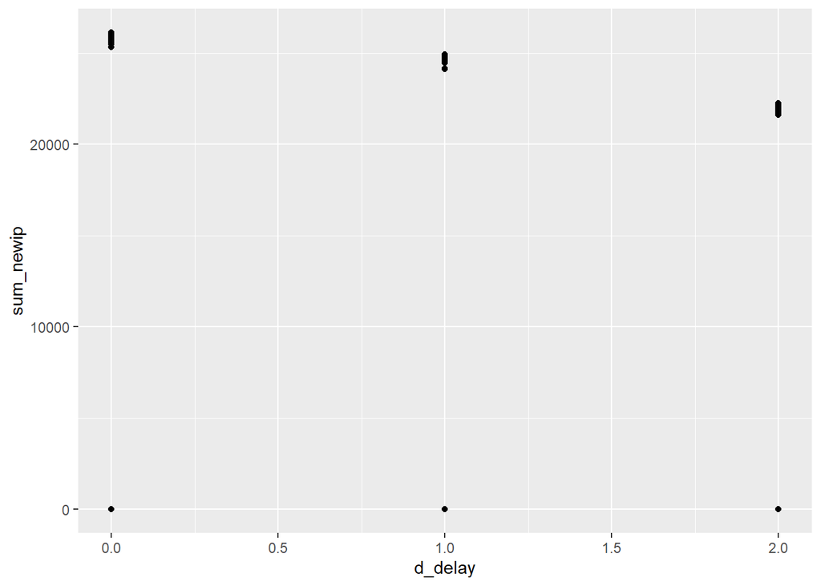

```r
## creating scatter plot and saving
# creating
plt_delay01 <- data02 %>%
            ggplot(.) +
            geom_point(aes(x = d_delay, y = sum_newip))
# plotting
plt_delay01
```

```r
# saving
plt_delay01 %>%
        ggsave(., filename = "./PlotsTables/plt_delay01.png",
               units = "cm",
               dpi = "retina",
               height = 8,
               width = 14)

## removing auxillary variables
rm(list= ls(pattern= "data"))
rm(list= ls(pattern= "res"))
rm(list= ls(pattern= "plt"))
rm(list= ls(pattern= "desc"))
```

#### 3. Contermeasure “Account Ban”

```r
## loading data
data03 <- read.csv2("./RawData/network_sim_ban_01_00_noip2_lstwt3_365_01.csv") %>%
    as.data.frame(.) %>%
    `colnames<-`(c("no_ban", "sum_newip",
                   "d_sim", "rem_acc"))

## getting descriptive statistics on base model (strength = 0)
desc03 <- data03 %>%
          filter(., no_ban == 0) %>%
          dplyr::select(., sum_newip)
summary(desc03)
```

```
##    sum_newip
##  Min.   :    0
##  1st Qu.:25531
##  Median :25599
##  Mean   :24764
##  3rd Qu.:25701
##  Max.   :25947
```

```r
desc03 %>%
  pull(.) %>%
  sd(.)
```

```
## [1] 4679.798
```

```r
## performing OLS
res03 <- data03 %>%
   lm(data = ., formula = sum_newip ~ no_ban)

## over entire strength variation
summary(res03)
```

```
##
## Call:
## lm(formula = sum_newip ~ no_ban, data = .)
##
## Residuals:
##      Min       1Q   Median       3Q      Max
## -24989.4    647.8    869.9   1088.3   1995.6
##
## Coefficients:
##              Estimate Std. Error t value Pr(>|t|)
## (Intercept) 24989.421    671.717   37.20  < 2e-16 ***
## no_ban        -26.315      3.939   -6.68 8.28e-10 ***
## ---
## Signif. codes:  0 '***' 0.001 '**' 0.01 '*' 0.05 '.' 0.1 ' ' 1
##
## Residual standard error: 4395 on 118 degrees of freedom
## Multiple R-squared:  0.2744, Adjusted R-squared:  0.2682
## F-statistic: 44.62 on 1 and 118 DF,  p-value: 8.283e-10
```

```r
## saving results
res03 %>%
   stargazer(.,
        style = "apsr",
        digits = 2,
        type = "html",
        out = "./PlotsTables/regres_ban_noip2_lstwt3_365_01.html")
```

```
##
## <table style="text-align:center"><tr><td colspan="2" style="border-bottom: 1px solid black"></td></tr><tr><td style="text-align:left"></td><td>sum_newip</td></tr>
## <tr><td colspan="2" style="border-bottom: 1px solid black"></td></tr><tr><td style="text-align:left">no_ban</td><td>-26.32<sup>***</sup></td></tr>
## <tr><td style="text-align:left"></td><td>(3.94)</td></tr>
## <tr><td style="text-align:left">Constant</td><td>24,989.42<sup>***</sup></td></tr>
## <tr><td style="text-align:left"></td><td>(671.72)</td></tr>
## <tr><td style="text-align:left">N</td><td>120</td></tr>
## <tr><td style="text-align:left">R<sup>2</sup></td><td>0.27</td></tr>
## <tr><td style="text-align:left">Adjusted R<sup>2</sup></td><td>0.27</td></tr>
## <tr><td style="text-align:left">Residual Std. Error</td><td>4,395.38 (df = 118)</td></tr>
## <tr><td style="text-align:left">F Statistic</td><td>44.62<sup>***</sup> (df = 1; 118)</td></tr>
## <tr><td colspan="2" style="border-bottom: 1px solid black"></td></tr><tr><td colspan="2" style="text-align:left"><sup>*</sup>p < .1; <sup>**</sup>p < .05; <sup>***</sup>p < .01</td></tr>
## </table>
```

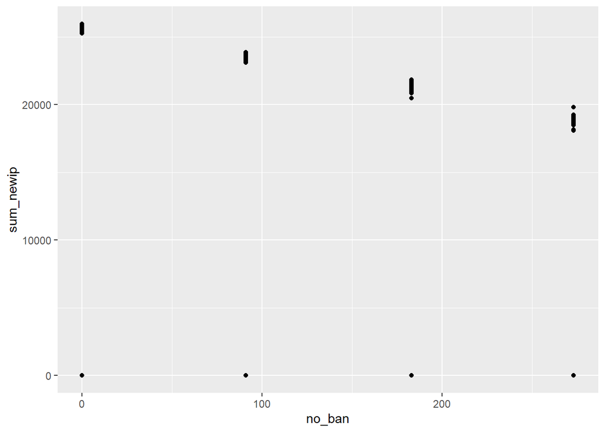

```r
## creating scatter plot and saving
# creating
plt_ban01 <- data03 %>%
              ggplot(.) +
              geom_point(aes(x = no_ban, y = sum_newip))
# plotting
plt_ban01
```

```r
# saving
plt_ban01 %>%
        ggsave(., filename = "./PlotsTables/plt_ban01.png",
               units = "cm",
               dpi = "retina",
               height = 8,
               width = 14)

## removing auxillary variables
rm(list= ls(pattern= "data"))
rm(list= ls(pattern= "res"))
rm(list= ls(pattern= "plt"))
rm(list= ls(pattern= "desc"))

## Repository ----------------------------------------------------------------------------
# p2 <- p1 +
#       geom_text(aes(x = 13, y = 1025,
#              label = "Ende Shutdown: 11. Mai"),
#              lineheight = 1.2,
#              hjust = 0,
#              vjust = 0,
#              colour = "black",
#              family="Helvetica",
#              size = 5.5) +
#
#      geom_curve(aes(x = 17, y = 990, xend = 18.8,  yend = 950),
#              colour = "black",
#              size = 0.5,
#              curvature = 0.3,
#              arrow = arrow(length = unit(0.03, "npc")))
#
# ## Anzeigen und Speichern
# p2
# ggsave(p2, filename = "./TablesFigures/stackedbar_tweets.png", dpi = "retina",
#        height = 8, width = 14)
```